# Fetch Assessment

Thong Nguyen

2023-02-21

## Introduction

The data of warehouse consists of 4 small datasets, showing different categories regard to receipts and other information of the products such as time, brands, stores that the products belong to. From these datasets, we can provide numerous insights on the pattern of customers’ purchase pattern in order to allocate products to different stores, or different sites, area, in order to maximize our profit. The following data and charts are supporting some reasonable inference that we can make from the data.

** Relational dataset ** These are data created by joining ‘receipt_items.csv’ and ‘receipts.csv’ based on user ID, suggesting these datasets have different features come from one receipt, some of which that can be helpful for our company might be:

- “ID”: represents a unique identifier for each receipt item, which can be useful for identifying and tracking individual purchases.
- “STORE_NAME”: provides insights on where the purchase was made, which can be useful for analyzing sales by store location or identifying popular shopping destinations.
- “PURCHASE_TIME”: provides insights on the time of purchase, which can be useful for analyzing sales trends by time of day or identifying peak shopping hours.
- “TOTAL_SPENT”: provides insights on the total amount spent on each purchase, which can be useful for analyzing sales trends over time, identifying popular products or product categories, and understanding customer behavior.
- “USER_ID”: provides information on the user who made the purchase, which can be useful for identifying individual purchasing patterns or analyzing customer demographics.
- “BARCODE.x”: provides insights on the barcode of the purchased item, which can be useful for identifying individual products and analyzing sales trends by product or product category.
- “ITEM_INDEX.x”: represents the index of the purchased item in the receipt, which can be useful for analyzing the order in which items were purchased and identifying popular item combinations.
- “NEEDS_FETCH_REVIEW” indicates whether the receipt item needs to be reviewed, which can be useful for identifying potential errors or issues with individual purchases.
- “QUANTITY_PURCHASED.x”:provide insights on the quantity of the purchased item, which can be useful for analyzing sales trends by product or product category and identifying popular package sizes.

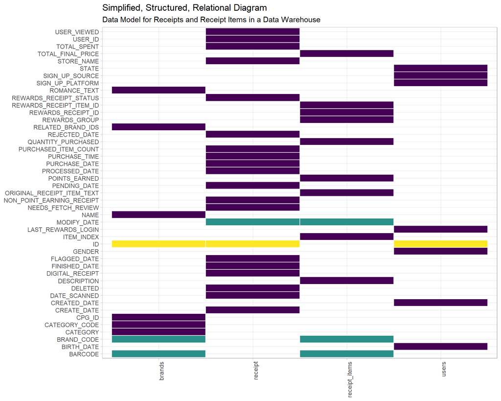

## Receipts & Receipt_items

- Overall, this dataset contains information about customer purchases, including the store location, purchase date and time, items purchased, and rewards points earned. However, the specifics of the information contained in the dataset will depend on the actual data. This dataset also appears to be related to customer purchases, specifically receipts. Columns such as “STORE_NAME,” “PURCHASE_DATE”, “PURCHASE_TIME”, and “TOTAL_SPENT” suggest information about the store where the purchase was made, the date and time of the purchase, and the total amount spent. Other columns, such as “USER_ID” and “USER_VIEWED,” contain information about individual customers and their interactions with the receipt data. There are also columns related to the items purchased, including “DESCRIPTION,” “BARCODE,” “BRAND_CODE,” “QUANTITY_PURCHASED,” and “TOTAL_FINAL_PRICE.” Additionally, there are columns related to rewards points earned, such as “POINTS_EARNED” and “REWARDS_GROUP.”

```
## # A tibble: 360,377 × 32
##    ID    STORE…¹ PURCHASE_DATE       PURCH…² DATE_SCANNED        TOTAL…³ REWAR…⁴
##    <chr> <chr>   <dttm>              <time>  <dttm>                <dbl> <chr>
##  1 6286… TOWN O… 2022-05-19 00:00:00 14:05   2022-05-19 18:41:42   860.  FINISH…
##  2 6269… FAMILY… 2022-04-27 00:00:00 16:15   2022-04-27 20:17:46    11   FINISH…
##  3 6269… FAMILY… 2022-04-27 00:00:00 16:15   2022-04-27 20:17:46    11   FINISH…
##  4 625b… PUBLIX  2022-04-15 00:00:00 16:45   2022-04-16 20:24:07    10.7 FINISH…
##  5 625b… PUBLIX  2022-04-15 00:00:00 16:45   2022-04-16 20:24:07    10.7 FINISH…
##  6 625b… PUBLIX  2022-04-15 00:00:00 16:45   2022-04-16 20:24:07    10.7 FINISH…
##  7 625b… PUBLIX  2022-04-15 00:00:00 16:45   2022-04-16 20:24:07    10.7 FINISH…
##  8 60e3… COSTCO  2021-06-30 00:00:00 13:16   2021-07-06 02:18:38    61.9 FINISH…
##  9 60e3… COSTCO  2021-06-30 00:00:00 13:16   2021-07-06 02:18:38    61.9 FINISH…
## 10 60e3… COSTCO  2021-06-30 00:00:00 13:16   2021-07-06 02:18:38    61.9 FINISH…
## # … with 360,367 more rows, 25 more variables: USER_ID <chr>,
## #   USER_VIEWED <lgl>, PURCHASED_ITEM_COUNT <dbl>, CREATE_DATE <dttm>,
## #   PENDING_DATE <dttm>, MODIFY_DATE.x <dttm>, FLAGGED_DATE <dttm>,
## #   PROCESSED_DATE <lgl>, FINISHED_DATE <dttm>, REJECTED_DATE <dttm>,
## #   NEEDS_FETCH_REVIEW <lgl>, DIGITAL_RECEIPT <lgl>, DELETED <lgl>,
## #   NON_POINT_EARNING_RECEIPT <lgl>, ITEM_INDEX <dbl>,
## #   REWARDS_RECEIPT_ITEM_ID <chr>, DESCRIPTION <chr>, BARCODE <chr>, …
```

```
## # A tibble: 3,165 × 19
##    ID.x       BARCODE BRAND…¹ CPG_ID CATEG…² CATEG…³ NAME  ROMAN…⁴ RELAT…⁵ ID.y
##    <chr>      <chr>   <chr>   <chr>  <chr>   <chr>   <chr> <chr>   <chr>   <chr>
##  1 5a8c35dde… 511111… PEPPER… 5a734… Grocery GROCERY Pepp… Pepper… <NA>    6272…
##  2 5a8c35dde… 511111… PEPPER… 5a734… Grocery GROCERY Pepp… Pepper… <NA>    6267…
##  3 5a8c35dde… 511111… PEPPER… 5a734… Grocery GROCERY Pepp… Pepper… <NA>    6267…
##  4 5a8c35dde… 511111… PEPPER… 5a734… Grocery GROCERY Pepp… Pepper… <NA>    62d1…
##  5 5a8c35dde… 511111… PEPPER… 5a734… Grocery GROCERY Pepp… Pepper… <NA>    61f4…
##  6 5a8c35dde… 511111… PEPPER… 5a734… Grocery GROCERY Pepp… Pepper… <NA>    61f4…
##  7 5a8c35dde… 511111… PEPPER… 5a734… Grocery GROCERY Pepp… Pepper… <NA>    6295…
##  8 5a8c35dde… 511111… PEPPER… 5a734… Grocery GROCERY Pepp… Pepper… <NA>    62d0…
##  9 5a8c35dde… 511111… PEPPER… 5a734… Grocery GROCERY Pepp… Pepper… <NA>    6272…
## 10 5a8c35dde… 511111… PEPPER… 5a734… Grocery GROCERY Pepp… Pepper… <NA>    62cd…
## # … with 3,155 more rows, 9 more variables: ITEM_INDEX <dbl>,
## #   REWARDS_RECEIPT_ITEM_ID <chr>, DESCRIPTION <chr>, QUANTITY_PURCHASED <dbl>,
## #   TOTAL_FINAL_PRICE <dbl>, POINTS_EARNED <dbl>, REWARDS_GROUP <chr>,
## #   ORIGINAL_RECEIPT_ITEM_TEXT <chr>, MODIFY_DATE <dttm>, and abbreviated
## #   variable names ¹BRAND_CODE, ²CATEGORY, ³CATEGORY_CODE, ⁴ROMANCE_TEXT,
## #   ⁵RELATED_BRAND_IDS
```

```
## # A tibble: 4 × 3
##   period    number_of_re_byperiod total_items
##   <chr>                     <int>       <dbl>
## 1 Afternoon                 27189      251739
## 2 Morning                   17253      131400
## 3 Evening                   12323       74435
## 4 Overnight                  8889       50021
```

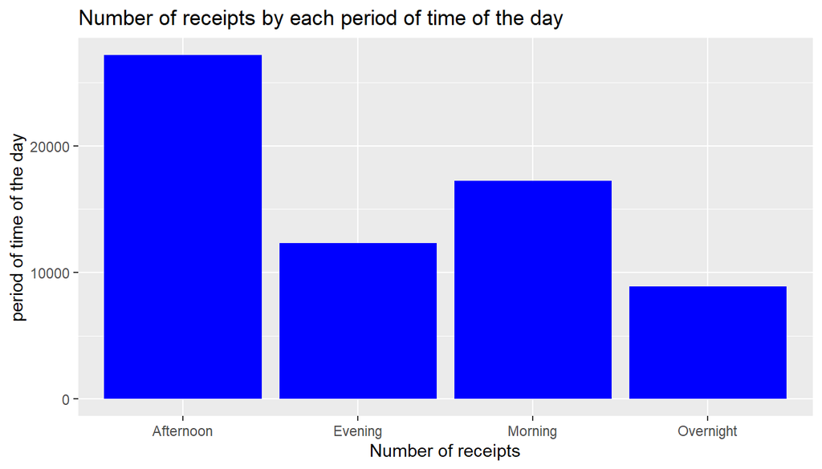

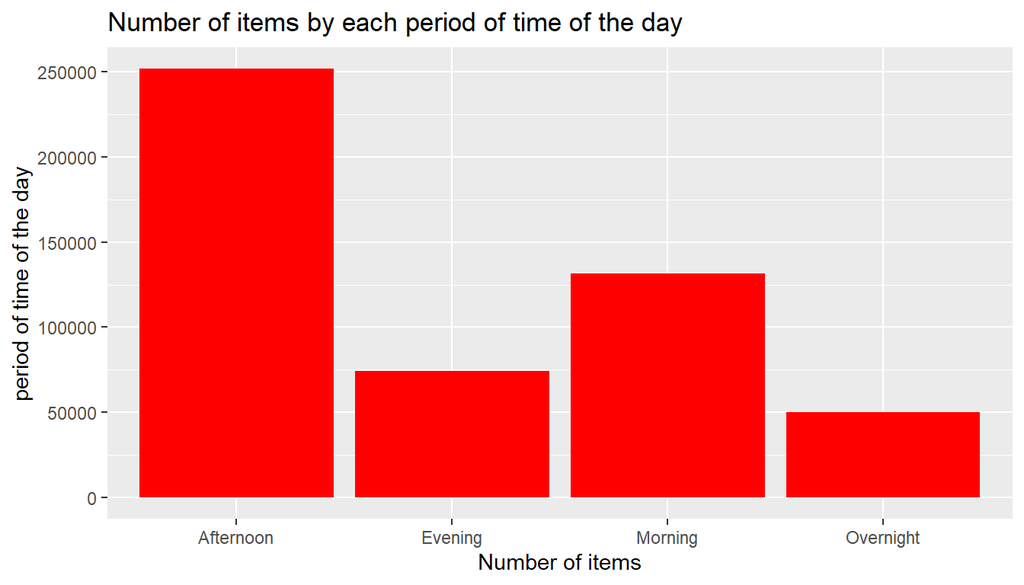

> What is the stores with the highest number of receipts?
- We can see that Walmart, Amazon, Target, Dunkin Donut are the most popular store, standing at rougly 6900, 2800, 1800, 1780, respectively, and suggesting that their service in the market are in good implementation

```
## # A tibble: 10 × 2
##    STORE_NAME             number_of_store
##    <chr>                            <int>
##  1 WALMART                           6931
##  2 AMAZON                            2778
##  3 TARGET                            1805
##  4 DUNKIN DONUTS                     1780
##  5 MCDONALD'S                        1632
##  6 DOLLAR TREE STORES INC            1403
##  7 WALGREENS                         1393
##  8 PUBLIX                            1224
##  9 COSTCO                            1102
## 10 SAM'S CLUB                         993
```

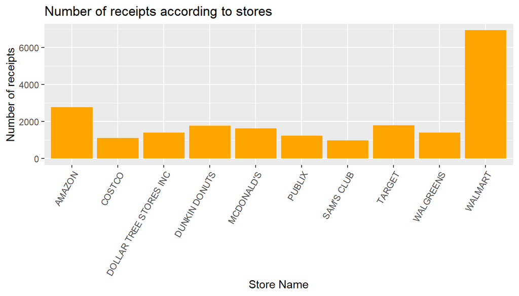

> Interesting fact: All of the top 5 with the highest number of receipts witnessed an increase in the number, with that of WALMART is the most significant

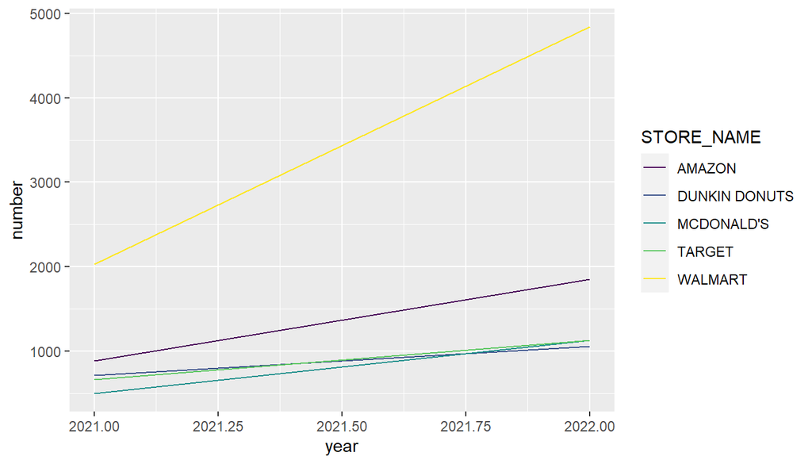

```
## # A tibble: 25 × 3
## # Groups:   year [3]
##     year month number
##    <dbl> <dbl>  <int>
##  1  2021     1    302
##  2  2021     2    525
##  3  2021     3    948
##  4  2021     4   1228
##  5  2021     5   1838
##  6  2021     6   1824
##  7  2021     7   2145
##  8  2021     8   2436
##  9  2021     9   2682
## 10  2021    10   3450
## # … with 15 more rows
```

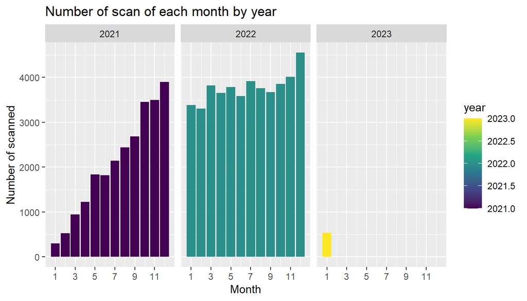

> What users data may suggest ?

```
## # A tibble: 16 × 4
## # Groups:   SIGN_UP_SOURCE [4]
##    GENDER            SIGN_UP_SOURCE number_of_signups number_by_source
##    <chr>             <chr>                      <int>            <int>
##  1 female            Apple                          6               42
##  2 male              Apple                         11               42
##  3 prefer_not_to_say Apple                         14               42
##  4 transgender       Apple                         11               42
##  5 female            Email                          6               29
##  6 male              Email                          6               29
##  7 prefer_not_to_say Email                         11               29
##  8 transgender       Email                          6               29
##  9 female            Google                         7               26
## 10 male              Google                         3               26
## 11 prefer_not_to_say Google                         6               26
## 12 transgender       Google                        10               26
## 13 female            Facebook                       9               22
## 14 male              Facebook                       4               22
## 15 prefer_not_to_say Facebook                       3               22
## 16 transgender       Facebook                       6               22
```

- As we can see most of the users sign up by Apple and Email. Regarding to genders, in these data, thosse who prefer no to say registers Apple the most, while female tend to use Facebook to sign up. Therefore, business stakeholder can put more advertises targeting female customers on Facebook.

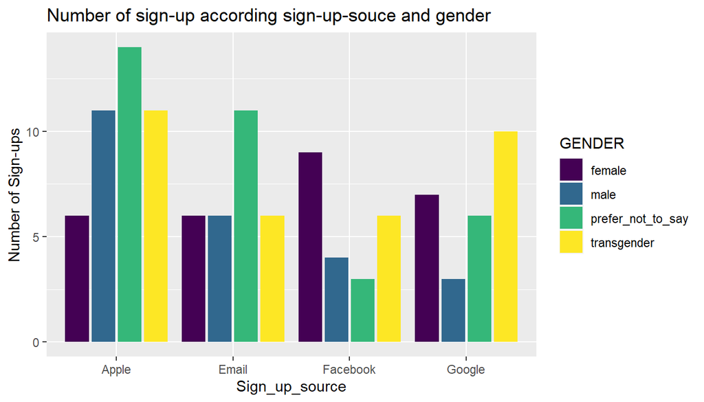

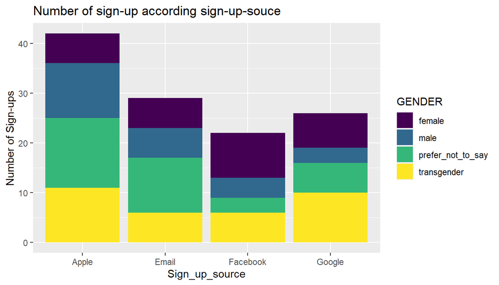

> Which state has the highest proportion of sign-ups?

```
## # A tibble: 36 × 3
##    STATE number_of_signups_state proportion
##    <chr>                   <int>      <dbl>
##  1 NY                         12     0.101
##  2 FL                         10     0.0840
##  3 CA                          9     0.0756
##  4 GA                          7     0.0588
##  5 NC                          7     0.0588
##  6 PA                          7     0.0588
##  7 TX                          6     0.0504
##  8 MI                          5     0.0420
##  9 PR                          5     0.0420
## 10 SC                          5     0.0420
## # … with 26 more rows
```

- As we can see, New York has the most number of sign-ups, followed by Florida and California. This suggest that these 3 regions are our potential target customers, accounting for 10%, 8%, and 7%, respectively. Therefore, businesses should target more on these potential market.

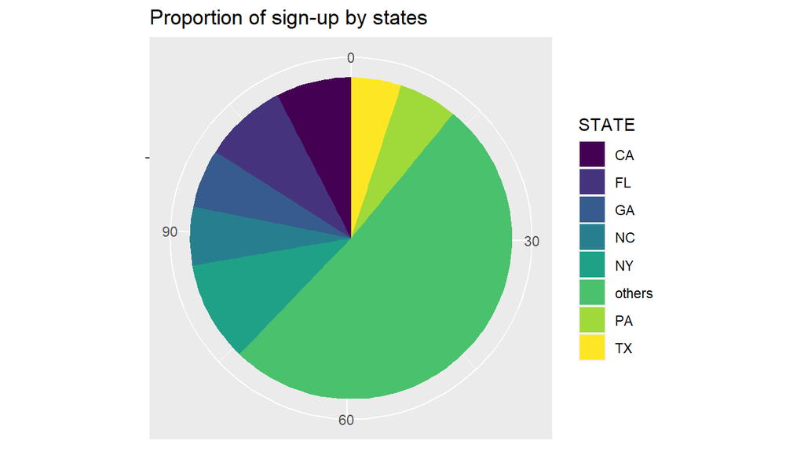

> Which month has the most sign-ups?
- As we can see, the last four months of the years generally has higher number of sign-ups. Therefore, the business must focus on this period of year

```
## # A tibble: 12 × 2
##    month   num
##    <ord> <int>
##  1 Jan      14
##  2 Feb      13
##  3 Mar      12
##  4 Apr      17
##  5 May      10
##  6 Jun       8
##  7 Jul      14
##  8 Aug      12
##  9 Sep      15
## 10 Oct      15
## 11 Nov      18
## 12 Dec      16
```

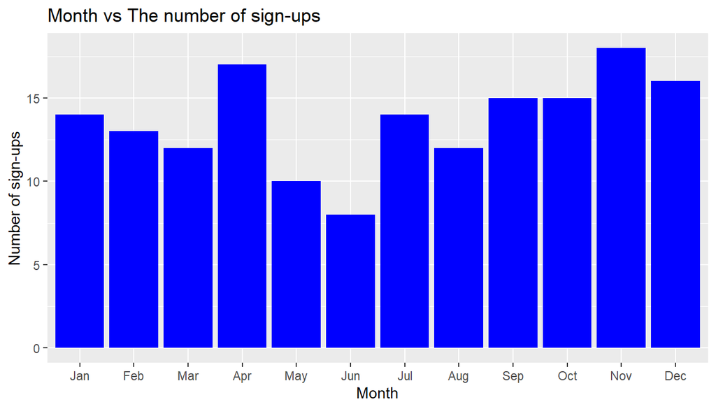

## Brands

The dataset contains information about customer purchases, particularly regarding rewards programs. There are columns related to the item purchased, such as “DESCRIPTION” and “TOTAL_FINAL_PRICE,” as well as columns related to rewards points earned, such as “POINTS_EARNED” and “REWARDS_GROUP.” There are also columns related to the brand and category of the item, such as “BRAND_CODE” and “CATEGORY_CODE.” The dataset may also contain information about multiple purchases made by the same customer, as there are columns related to “REWARDS_RECEIPT_ITEM_ID” and “ITEM_INDEX”. Overall, we can assume that the dataset contains information about customer purchases, rewards points earned, and information about the items purchased, including brand and category.

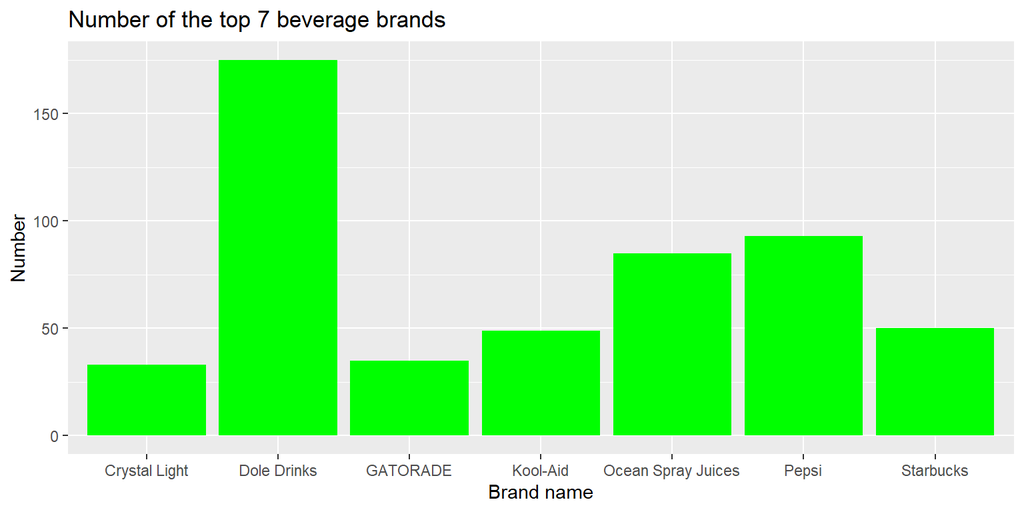

```
## # A tibble: 4 × 2
##   TOTAL_FINAL_PRICE ORIGINAL_RECEIPT_ITEM_TEXT
##               <dbl> <chr>
## 1              6.49 PF CHOCFUDG CAKE
## 2              6.38 Pepperidge Farm Cinnamon Swirl Bread - 16oz
## 3              6.16 PF TOP SLICE HOT DOG BUN
## 4              5.29 PF CHOCFUDG CAKE
```

```r
colnames(brands)
```

```
##  [1] "ID.x"                       "BARCODE"
##  [3] "BRAND_CODE"                 "CPG_ID"
##  [5] "CATEGORY"                   "CATEGORY_CODE"
##  [7] "NAME"                       "ROMANCE_TEXT"
##  [9] "RELATED_BRAND_IDS"          "ID.y"
## [11] "ITEM_INDEX"                 "REWARDS_RECEIPT_ITEM_ID"
## [13] "DESCRIPTION"                "QUANTITY_PURCHASED"
## [15] "TOTAL_FINAL_PRICE"          "POINTS_EARNED"
## [17] "REWARDS_GROUP"              "ORIGINAL_RECEIPT_ITEM_TEXT"
## [19] "MODIFY_DATE"
```